# Cyclist Bike Share Analysis - Samarth

#Step 1 (Collect Data) #Load packages

```r
library(tidyverse)
library(janitor)
library(lubridate)
library(skimr)
```

#Load individual dataframes

```r
oct_2020 <- read_excel("Trip Data/Analysis Files/Excel Files/2020_10.xlsx")
nov_2020 <- read_excel("Trip Data/Analysis Files/Excel Files/2020_11.xlsx")
dec_2020 <- read_excel("Trip Data/Analysis Files/Excel Files/2020_12.xlsx")
jan_2021 <- read_excel("Trip Data/Analysis Files/Excel Files/2021_01.xlsx")
feb_2021 <- read_excel("Trip Data/Analysis Files/Excel Files/2021_02.xlsx")
mar_2021 <- read_excel("Trip Data/Analysis Files/Excel Files/2021_03.xlsx")
apr_2021 <- read_excel("Trip Data/Analysis Files/Excel Files/2021_04.xlsx")
may_2021 <- read_excel("Trip Data/Analysis Files/Excel Files/2021_05.xlsx")
jun_2021 <- read_excel("Trip Data/Analysis Files/Excel Files/2021_06.xlsx")
jul_2021 <- read_excel("Trip Data/Analysis Files/Excel Files/2021_07.xlsx")
aug_2021 <- read_excel("Trip Data/Analysis Files/Excel Files/2021_08.xlsx")
sep_2021 <- read_excel("Trip Data/Analysis Files/Excel Files/2021_09.xlsx")
```

#Step 2 (Clean Data) #Inspect Data

```r
compare_df_cols(oct_2020,nov_2020,dec_2020,jan_2021,feb_2021,mar_2021,apr_2021,may_2021,jun_2021,jul_2021,aug_2021,sep_2021, return = 'mismatch')
```

| column_name | oct_2020 | nov_2020 | dec_2020 | jan_2021 | feb_2021 | mar_2021 | apr_2021 | may_2021 | jun_2021 | jul_2021 | aug_2021 | sep_2021 |
| --- | --- | --- | --- | --- | --- | --- | --- | --- | --- | --- | --- | --- |
| end_station_id | numeric | numeric | character | character | character | character | character | character | character | character | character | character |
| start_station_id | numeric | numeric | character | character | character | character | character | character | character | character | character | character |

#Since october and november have start_station_df and end_station_id as numeric data type, we need to convert them to character so that they can be correctly bound into a single dataframe

```r
oct_2020 <- mutate(oct_2020, start_station_id = as.character(start_station_id),
              end_station_id = as.character(end_station_id))
nov_2020 <- mutate(nov_2020, start_station_id = as.character(start_station_id),
              end_station_id = as.character(end_station_id))
```

#Check for column data type mismatch again

| column_name | oct_2020 | nov_2020 | dec_2020 | jan_2021 | feb_2021 | mar_2021 | apr_2021 | may_2021 | jun_2021 | jul_2021 | aug_2021 | sep_2021 |
| --- | --- | --- | --- | --- | --- | --- | --- | --- | --- | --- | --- | --- |

```r
str(nov_2020)
```

```
tibble [259,716 x 15] (S3: tbl_df/tbl/data.frame)
 $ ride_id           : chr [1:259716] "BD0A6FF6FFF9B921" "96A7A7A4BDE4F82D" "C61526D06582BDC5" "E533E89C32080B9E" ...
 $ rideable_type     : chr [1:259716] "electric_bike" "electric_bike" "electric_bike" "electric_bike" ...
 $ started_at        : POSIXct[1:259716], format: "2020-11-01 13:36:00" "2020-11-01 10:03:00" "2020-11-01 00:34:00" "2020-11-01 00:45:00" ...
 $ ended_at          : POSIXct[1:259716], format: "2020-11-01 13:45:00" "2020-11-01 10:14:00" "2020-11-01 01:03:00" "2020-11-01 00:54:00" ...
 $ start_station_name: chr [1:259716] "Dearborn St & Erie St" "Franklin St & Illinois St" "Lake Shore Dr & Monroe St" "Leavitt St & Chicago Ave" ...
 $ start_station_id  : chr [1:259716] "110" "672" "76" "659" ...
 $ end_station_name  : chr [1:259716] "St. Clair St & Erie St" "Noble St & Milwaukee Ave" "Federal St & Polk St" "Stave St & Armitage Ave" ...
 $ end_station_id    : chr [1:259716] "211" "29" "41" "185" ...
 $ start_lat         : num [1:259716] 41.9 41.9 41.9 41.9 41.9 ...
 $ start_lng         : num [1:259716] -87.6 -87.6 -87.6 -87.7 -87.6 ...
 $ end_lat           : num [1:259716] 41.9 41.9 41.9 41.9 41.9 ...
 $ end_lng           : num [1:259716] -87.6 -87.7 -87.6 -87.7 -87.6 ...
 $ member_casual     : chr [1:259716] "casual" "casual" "casual" "casual" ...
 $ ride_length       : POSIXct[1:259716], format: "1899-12-31 00:09:00" "1899-12-31 00:11:00" "1899-12-31 00:29:00" "1899-12-31 00:09:00" ...
 $ day_of_week       : num [1:259716] 1 1 1 1 1 7 7 7 7 7 ...
```

```r
colnames(master_df)
```

```
 [1] "ride_id"            "rideable_type"      "started_at"         "ended_at"           "start_station_name" "start_station_id"   "end_station_name"
 [8] "end_station_id"     "start_lat"          "start_lng"          "end_lat"            "end_lng"            "member_casual"      "ride_length"
[15] "day_of_week"
```

#Select relevant columns

```r
master_df <- subset(master_df, select = -c(start_lat,start_lng,end_lat,end_lng,ride_length,day_of_week,ride_length,day_of_week)) #I'm removing two columns (ride_length and day_of_week) which were calculated using spreadsheet functions for Excel Analyis.
```

```r
dim(master_df)
```

```
[1] 5136261       9
```

```r
str(master_df)
```

```
tibble [5,136,261 x 9] (S3: tbl_df/tbl/data.frame)
 $ ride_id           : chr [1:5136261] "ACB6B40CF5B9044C" "DF450C72FD109C01" "B6396B54A15AC0DF" "44A4AEE261B9E854" ...
 $ rideable_type     : chr [1:5136261] "electric_bike" "electric_bike" "electric_bike" "electric_bike" ...
 $ started_at        : POSIXct[1:5136261], format: "2020-10-31 19:39:43" "2020-10-31 23:50:08" "2020-10-31 23:00:01" "2020-10-31 22:16:43" ...
 $ ended_at          : POSIXct[1:5136261], format: "2020-10-31 19:57:12" "2020-11-01 00:04:16" "2020-10-31 23:08:22" "2020-10-31 22:19:35" ...
 $ start_station_name: chr [1:5136261] "Lakeview Ave & Fullerton Pkwy" "Southport Ave & Waveland Ave" "Stony Island Ave & 67th St" "Clark St & Grace St" ...
 $ start_station_id  : chr [1:5136261] "313" "227" "102" "165" ...
 $ end_station_name  : chr [1:5136261] "Rush St & Hubbard St" "Kedzie Ave & Milwaukee Ave" "University Ave & 57th St" "Broadway & Sheridan Rd" ...
 $ end_station_id    : chr [1:5136261] "125" "260" "423" "256" ...
 $ member_casual     : chr [1:5136261] "casual" "casual" "casual" "casual" ...
```

```r
summary(master_df)
```

```
   ride_id          rideable_type        started_at                     ended_at                   start_station_name start_station_id   end_station_name
 Length:5136261     Length:5136261     Min.   :2020-10-01 00:00:06   Min.   :2020-10-01 00:05:09   Length:5136261     Length:5136261     Length:5136261
 Class :character   Class :character   1st Qu.:2021-04-11 18:50:57   1st Qu.:2021-04-11 19:15:05   Class :character   Class :character   Class :character
 Mode  :character   Mode  :character   Median :2021-06-21 18:01:31   Median :2021-06-21 18:20:59   Mode  :character   Mode  :character   Mode  :character
                                       Mean   :2021-05-25 22:30:55   Mean   :2021-05-25 22:51:33
                                       3rd Qu.:2021-08-11 21:13:51   3rd Qu.:2021-08-11 21:33:57
                                       Max.   :2021-09-30 23:59:48   Max.   :2021-10-01 22:55:35
 end_station_id     member_casual
 Length:5136261     Length:5136261
 Class :character   Class :character
 Mode  :character   Mode  :character
```

```r
skim(master_df)
```

```
-- Data Summary ------------------------
                           Values
Name                       master_df
Number of rows             5136261
Number of columns          9
_______________________
Column type frequency:
  character                7
  POSIXct                  2
________________________
Group variables            None

-- Variable type: character ---------------------------------------------------------------------------------------------------------------------------------------------
# A tibble: 7 x 8
  skim_variable      n_missing complete_rate   min   max empty n_unique whitespace
* <chr>                  <int>         <dbl> <int> <int> <int>    <int>      <int>
1 ride_id                    0         1         5    23     0  5136052          0
2 rideable_type              0         1        11    13     0        3          0
3 start_station_name    523467         0.898     3    53     0      784          0
4 start_station_id      523781         0.898     1    36     0     1288          0
5 end_station_name      567268         0.890    10    53     0      781          0
6 end_station_id        567501         0.890     1    36     0     1288          0
7 member_casual              0         1         6     6     0        2          0

-- Variable type: POSIXct -----------------------------------------------------------------------------------------------------------------------------------------------
# A tibble: 2 x 7
  skim_variable n_missing complete_rate min                 max                 median              n_unique
* <chr>             <int>         <dbl> <dttm>              <dttm>              <dttm>                 <int>
1 started_at            0             1 2020-10-01 00:00:06 2021-09-30 23:59:48 2021-06-21 18:01:31  4103233
2 ended_at              0             1 2020-10-01 00:05:09 2021-10-01 22:55:35 2021-06-21 18:20:59  4095094
```

#Since we removed ride_length and day_of_week to show how they are done with the help of R, we add columns to indicate the day, month and year for each record

```r
master_df$date <- as.Date(master_df$started_at)
```

#Use strftime function to strip year, month and day from date column we created

```r
master_df$year <- strftime(master_df$date, "%Y")
master_df$month <- strftime(master_df$date, "%m")
master_df$day_of_month <- strftime(master_df$date, "%d")
master_df$day_of_week <- strftime(master_df$date, "%A")
```

#Add ride_length column using difftime

```r
master_df$ride_length <- difftime(master_df$ended_at,master_df$started_at)
```

#Inspect new column

```r
is.numeric(master_df)
```

```
[1] FALSE
```

```r
is.factor(master_df$ride_length)
```

```
[1] FALSE
```

#Check new column

```r
summary(master_df$ride_length)
```

```
    Min.  1st Qu.   Median     Mean  3rd Qu.     Max.
-1742998      424      756     1237     1369  3356649
```

#ride_length cannot be negative, select rows which are positive (new master dataframe will be created since we will be removing a lot of rows) #remove start station name for trips where bikes were taken away for quality check

```r
master_df_2 <- master_df[!(master_df$start_station_name == "HQ QR" | master_df$ride_length < 0)]
```

[output not shown]

#Inspect new dataframe

```r
summary(master_df_2)
```

```
   ride_id          rideable_type        started_at                     ended_at                   start_station_name start_station_id   end_station_name
 Length:5132742     Length:5132742     Min.   :2020-10-01 00:00:06   Min.   :2020-10-01 00:05:09   Length:5132742     Length:5132742     Length:5132742
 Class :character   Class :character   1st Qu.:2021-04-09 08:09:17   1st Qu.:2021-04-09 08:26:59   Class :character   Class :character   Class :character
 Mode  :character   Mode  :character   Median :2021-06-20 09:42:17   Median :2021-06-20 10:11:09   Mode  :character   Mode  :character   Mode  :character
                                       Mean   :2021-05-24 16:04:24   Mean   :2021-05-24 16:27:49
                                       3rd Qu.:2021-08-10 19:00:19   3rd Qu.:2021-08-10 19:19:00
                                       Max.   :2021-09-30 23:59:48   Max.   :2021-10-01 22:55:35
                                       NA's   :523409                NA's   :523409
 end_station_id     member_casual           date                year              month           day_of_month       day_of_week         ride_length
 Length:5132742     Length:5132742     Min.   :2020-10-01   Length:5132742     Length:5132742     Length:5132742     Length:5132742     Min.   :      0
 Class :character   Class :character   1st Qu.:2021-04-09   Class :character   Class :character   Class :character   Class :character   1st Qu.:    431
 Mode  :character   Mode  :character   Median :2021-06-20   Mode  :character   Mode  :character   Mode  :character   Mode  :character   Median :    764
                                       Mean   :2021-05-24                                                                               Mean   :   1405
                                       3rd Qu.:2021-08-10                                                                               3rd Qu.:   1382
                                       Max.   :2021-09-30                                                                               Max.   :3356649
                                       NA's   :523409                                                                                   NA's   :523409
```

#Removing rows with NA across all columns

```r
master_df_2 <- na.omit(master_df_2)
```

#Step 4: Descriptive Analysis

```r
summary(master_df_2$ride_length)
```

```
   Min. 1st Qu.  Median    Mean 3rd Qu.    Max.
      0     432     763    1359    1380 3356649
```

#Compare casual users to members

| member_casual | min_ride_length | median_ride_length | average_ride_length | max_ride_length |
| --- | --- | --- | --- | --- |
| casual | 0 | 1032 | 2012.9390 | 3356649 |
| member | 0 | 605 | 821.7529 | 573467 |

#Casual riders ride more on average, and we can now check the average ride length by days (Order the days first so that it’s easier)

```r
master_df_2$day_of_week <- ordered(master_df_2$day_of_week, levels = c('Sunday','Monday','Tuesday','Wednesday','Thursday','Friday','Saturday'))
```

#Average daily ride time for both members and casual riders

| master_df_2$member_casual | master_df_2$day_of_week | master_df_2$ride_length |
| --- | --- | --- |
| casual | Sunday | 2322.3825 |
| member | Sunday | 935.9325 |
| casual | Monday | 1993.7213 |
| member | Monday | 787.6146 |
| casual | Tuesday | 1803.9136 |
| member | Tuesday | 774.8611 |
| casual | Wednesday | 1753.5735 |
| member | Wednesday | 777.8053 |
| casual | Thursday | 1724.7195 |
| member | Thursday | 771.1657 |

[output cut: 4 more lines]

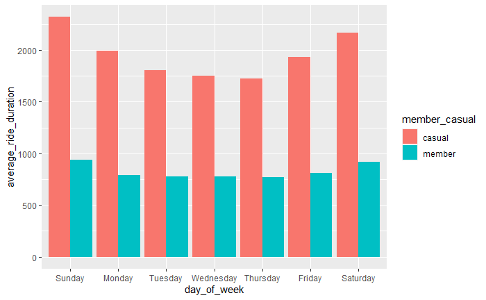

```r
master_df_2 %>%
  group_by(member_casual, day_of_week) %>%
  summarize(rides = n(),
            average_ride_duration = mean(ride_length)) %>%
  arrange(member_casual,day_of_week) %>%
  ggplot(aes(x=day_of_week,y=average_ride_duration,fill=member_casual)) +
  geom_col(position = 'dodge')
```

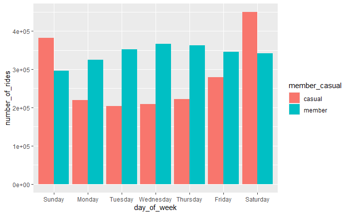

```r
master_df_2 %>%
  group_by(member_casual,day_of_week) %>%
  summarize(number_of_rides = n(),
            average_duration = mean(ride_length)) %>%
  arrange(member_casual, day_of_week) %>%
  ggplot(aes(x=day_of_week,y=number_of_rides, fill=member_casual)) +
  geom_col(position = 'dodge')
```

#We can aggregate daily ride, average duration of rides and number of rides

```r
master_df_2 %>%
  group_by(member_casual,day_of_week) %>%
  summarize(number_of_ride=n(),average_duration=mean(ride_length)) %>%
  arrange(member_casual,day_of_week)
```

| member_casual | day_of_week | number_of_ride | average_duration |
| --- | --- | --- | --- |
| casual | Sunday | 381857 | 2322.3825 |
| casual | Monday | 218997 | 1993.7213 |
| casual | Tuesday | 203467 | 1803.9136 |
| casual | Wednesday | 208457 | 1753.5735 |
| casual | Thursday | 222445 | 1724.7195 |
| casual | Friday | 278600 | 1932.5006 |
| casual | Saturday | 449435 | 2166.8320 |
| member | Sunday | 295714 | 935.9325 |
| member | Monday | 324110 | 787.6146 |
| member | Tuesday | 351391 | 774.8611 |

[output cut: 4 more lines]

#Now we can export file for furter analysis